# COM747 Week 6: Ethics, Evaluation and Logistic Regression

## A3. Choosing a threshold

```r
# Use the full mtcars data (in-sample, for illustration) to see the trade-off
full <- glm(am ~ wt, data = mtcars, family = binomial)
p <- predict(full, type = "response")
sapply(c(0.3, 0.5, 0.7), function(t) {
  pred <- ifelse(p > t, "manual", "automatic")
  c(threshold   = t,
    sensitivity = mean(pred[mtcars$am == "manual"] == "manual"),
    specificity = mean(pred[mtcars$am == "automatic"] == "automatic"))
})
```

```
##                  [,1]      [,2]      [,3]
## threshold   0.3000000 0.5000000 0.7000000
## sensitivity 0.9230769 0.8461538 0.7692308
## specificity 0.8421053 0.9473684 0.9473684
```

# Part B: Seminar exercises (complete solutions)

## B1. caret: k-NN exactly as on the sheet

```r
data <- read.csv("data.csv")
data <- data[, c(1:32)]                     # first 32 columns: drops the empty "X" column
data$diagnosis <- factor(data$diagnosis)    # caret needs a factor for classification
```

**Two fixes to the sheet’s code.** (1) Without `factor()`, `confusionMatrix()` fails because the label is text. (2) The PDF version writes `partitiion` (typo) on two lines; it must match `partition`.

```r
set.seed(1)
partition    <- createDataPartition(data$diagnosis, p = 0.7, list = FALSE)   # p = proportion for training
trainingData <- data[partition, ]
testData     <- data[-partition, ]
nrow(trainingData); nrow(testData)
```

```
## [1] 399
```

```
## [1] 170
```

```r
model <- train(diagnosis ~ ., method = "knn", data = trainingData)
model    # caret tried k = 5, 7, 9 with bootstrap resampling and kept the best
```

```
## k-Nearest Neighbors
##
## 399 samples
##  31 predictor
##   2 classes: 'B', 'M'
##
## No pre-processing
## Resampling: Bootstrapped (25 reps)
## Summary of sample sizes: 399, 399, 399, 399, 399, 399, ...
## Resampling results across tuning parameters:
##
##   k  Accuracy   Kappa
##   5  0.7199124  0.3604594
##   7  0.7166201  0.3440979
##   9  0.7088354  0.3246327
##
## Accuracy was used to select the optimal model using the largest value.
## The final value used for the model was k = 5.
```

```r
testingTheModel <- predict(model, newdata = testData)
confusionMatrix(testingTheModel, testData$diagnosis)
```

```
## Confusion Matrix and Statistics
##
##           Reference
## Prediction  B  M
##          B 95 35
##          M 12 28
##
##                Accuracy : 0.7235
##                  95% CI : (0.6498, 0.7893)
##     No Information Rate : 0.6294
##     P-Value [Acc > NIR] : 0.006126
##
##                   Kappa : 0.3593
##
##  Mcnemar's Test P-Value : 0.001332
##
##             Sensitivity : 0.8879
##             Specificity : 0.4444
##          Pos Pred Value : 0.7308
##          Neg Pred Value : 0.7000
##              Prevalence : 0.6294
##          Detection Rate : 0.5588
##    Detection Prevalence : 0.7647
##       Balanced Accuracy : 0.6661
##
##        'Positive' Class : B
##
```

```r
table(testData$diagnosis)      # NIR = 107 / 170
```

```
##
##   B   M
## 107  63
```

**Why is this only ~72%?** The formula `diagnosis ~ .` uses *every other column*, including `id`. IDs are numbers in the millions, so in a distance-based method like k-NN they dominate every other feature, and they carry no medical information. This is a form of **data leakage / bad feature** problem.

```r
prop.test(c(123, 107), c(170, 170))   # 123 correct vs NIR of 107: is the difference significant?
```

```
##
##  2-sample test for equality of proportions with continuity correction
##
## data:  c(123, 107) out of c(170, 170)
## X-squared = 3.0237, df = 1, p-value = 0.08206
## alternative hypothesis: two.sided
## 95 percent confidence interval:
##  -0.01071374  0.19894903
## sample estimates:
##    prop 1    prop 2
## 0.7235294 0.6294118
```

## B2. The fix: drop id and scale

```r
set.seed(1)
model_fixed <- train(diagnosis ~ . - id, method = "knn", data = trainingData,
                     preProcess = c("center", "scale"))   # standardise inside caret
model_fixed
```

```
## k-Nearest Neighbors
##
## 399 samples
##  31 predictor
##   2 classes: 'B', 'M'
##
## Pre-processing: centered (30), scaled (30)
## Resampling: Bootstrapped (25 reps)
## Summary of sample sizes: 399, 399, 399, 399, 399, 399, ...
## Resampling results across tuning parameters:
##
##   k  Accuracy   Kappa
##   5  0.9582099  0.9101699
##   7  0.9579840  0.9094797
##   9  0.9578955  0.9092667
##
## Accuracy was used to select the optimal model using the largest value.
## The final value used for the model was k = 5.
```

```r
pred_fixed <- predict(model_fixed, newdata = testData)
confusionMatrix(pred_fixed, testData$diagnosis, positive = "M")
```

```
## Confusion Matrix and Statistics
##
##           Reference
## Prediction   B   M
##          B 107   5
##          M   0  58
##
##                Accuracy : 0.9706
##                  95% CI : (0.9327, 0.9904)
##     No Information Rate : 0.6294
##     P-Value [Acc > NIR] : < 2e-16
##
##                   Kappa : 0.9359
##
##  Mcnemar's Test P-Value : 0.07364
##
##             Sensitivity : 0.9206
##             Specificity : 1.0000
##          Pos Pred Value : 1.0000
##          Neg Pred Value : 0.9554
##              Prevalence : 0.3706
##          Detection Rate : 0.3412
##    Detection Prevalence : 0.3412
##       Balanced Accuracy : 0.9603
##
##        'Positive' Class : M
##
```

```r
prop.test(c(sum(pred_fixed == testData$diagnosis), 107), c(170, 170))   # now far above the NIR
```

```
##
##  2-sample test for equality of proportions with continuity correction
##
## data:  c(sum(pred_fixed == testData$diagnosis), 107) out of c(170, 170)
## X-squared = 59.724, df = 1, p-value = 1.091e-14
## alternative hypothesis: two.sided
## 95 percent confidence interval:
##  0.2583797 0.4239733
## sample estimates:
##    prop 1    prop 2
## 0.9705882 0.6294118
```

## B3. 10-fold cross-validation

```r
control <- trainControl(method = "repeatedcv", number = 10, savePredictions = TRUE)
set.seed(1)
model <- train(diagnosis ~ . - id, method = "knn", data = trainingData,
               trControl = control, preProcess = c("center", "scale"))
model
```

```
## k-Nearest Neighbors
##
## 399 samples
##  31 predictor
##   2 classes: 'B', 'M'
##
## Pre-processing: centered (30), scaled (30)
## Resampling: Cross-Validated (10 fold, repeated 1 times)
## Summary of sample sizes: 359, 359, 359, 359, 359, 359, ...
## Resampling results across tuning parameters:
##
##   k  Accuracy   Kappa
##   5  0.9623077  0.9182904
##   7  0.9623077  0.9182904
##   9  0.9598077  0.9122865
##
## Accuracy was used to select the optimal model using the largest value.
## The final value used for the model was k = 7.
```

```r
cv <- model$pred
head(cv)
```

```
##   pred obs rowIndex k    Resample
## 1    M   M       11 5 Fold01.Rep1
## 2    M   M       18 5 Fold01.Rep1
## 3    M   M       21 5 Fold01.Rep1
## 4    B   B       37 5 Fold01.Rep1
## 5    M   M       39 5 Fold01.Rep1
## 6    B   B       62 5 Fold01.Rep1
```

```r
table(model$pred$Resample)   # ~40 rows per fold x 3 values of k = ~120 predictions per fold
```

```
##
## Fold01.Rep1 Fold02.Rep1 Fold03.Rep1 Fold04.Rep1 Fold05.Rep1 Fold06.Rep1
##         120         120         120         120         120         120
## Fold07.Rep1 Fold08.Rep1 Fold09.Rep1 Fold10.Rep1
##         120         120         120         117
```

## B4. Other algorithms: SVM and more

```r
length(names(getModelInfo()))   # hundreds of methods available through one interface
```

```
## [1] 239
```

```r
set.seed(1)
svm_model <- train(diagnosis ~ . - id, method = "svmLinear", data = trainingData,
                   trControl = control, preProcess = c("center", "scale"))
svm_model
```

```
## Support Vector Machines with Linear Kernel
##
## 399 samples
##  31 predictor
##   2 classes: 'B', 'M'
##
## Pre-processing: centered (30), scaled (30)
## Resampling: Cross-Validated (10 fold, repeated 1 times)
## Summary of sample sizes: 359, 359, 359, 359, 359, 359, ...
## Resampling results:
##
##   Accuracy   Kappa
##   0.9749359  0.9461486
##
## Tuning parameter 'C' was held constant at a value of 1
```

```r
table(svm_model$pred$Resample)    # one value of C, so ~40 predictions per fold
```

```
##
## Fold01.Rep1 Fold02.Rep1 Fold03.Rep1 Fold04.Rep1 Fold05.Rep1 Fold06.Rep1
##          40          40          40          40          40          40
## Fold07.Rep1 Fold08.Rep1 Fold09.Rep1 Fold10.Rep1
##          40          40          40          39
```

```r
confusionMatrix(predict(svm_model, testData), testData$diagnosis, positive = "M")
```

```
## Confusion Matrix and Statistics
##
##           Reference
## Prediction   B   M
##          B 106   5
##          M   1  58
##
##                Accuracy : 0.9647
##                  95% CI : (0.9248, 0.9869)
##     No Information Rate : 0.6294
##     P-Value [Acc > NIR] : <2e-16
##
##                   Kappa : 0.9233
##
##  Mcnemar's Test P-Value : 0.2207
##
##             Sensitivity : 0.9206
##             Specificity : 0.9907
##          Pos Pred Value : 0.9831
##          Neg Pred Value : 0.9550
##              Prevalence : 0.3706
##          Detection Rate : 0.3412
##    Detection Prevalence : 0.3471
##       Balanced Accuracy : 0.9556
##
##        'Positive' Class : M
##
```

## B5. Compare a range of models on one graph

```r
methods <- c(kNN = "knn", SVM = "svmLinear", Tree = "rpart", RandomForest = "rf", Logistic = "glm")
fits <- lapply(methods, function(m) {
  set.seed(1)    # same folds for every model, so the comparison is fair
  suppressWarnings(train(diagnosis ~ . - id, method = m, data = trainingData,
                         trControl = trainControl(method = "cv", number = 10),
                         preProcess = c("center", "scale")))
})
results <- resamples(fits)
summary(results)$statistics$Accuracy
```

```
##                   Min.   1st Qu. Median      Mean   3rd Qu.  Max. NA's
## kNN          0.9230769 0.9562500  0.975 0.9623077 0.9750000 0.975    0
## SVM          0.9500000 0.9560897  0.975 0.9749359 0.9937500 1.000    0
## Tree         0.8750000 0.9000000  0.925 0.9297436 0.9500000 1.000    0
## RandomForest 0.9000000 0.9562500  0.975 0.9648077 0.9750000 1.000    0
## Logistic     0.9250000 0.9500000  0.950 0.9549359 0.9748397 0.975    0
```

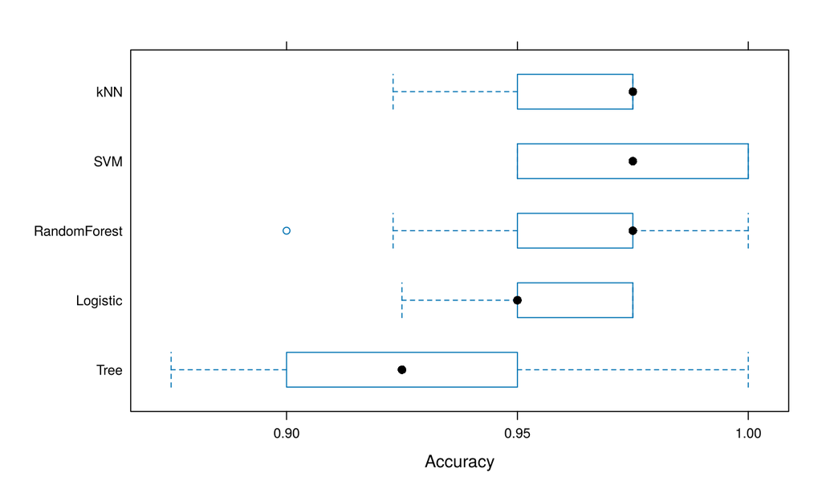

```r
bwplot(results, metric = "Accuracy")   # spread of the 10 fold accuracies per model
```

```r
# Test-set metrics for each model
test_metrics <- t(sapply(fits, function(f) {
  cm <- confusionMatrix(predict(f, testData), testData$diagnosis, positive = "M")
  round(c(cm$overall[c("Accuracy", "Kappa")], cm$byClass[c("Sensitivity", "Specificity")]), 3)
}))
test_metrics
```

```
##              Accuracy Kappa Sensitivity Specificity
## kNN             0.965 0.923       0.905       1.000
## SVM             0.965 0.923       0.921       0.991
## Tree            0.924 0.838       0.921       0.925
## RandomForest    0.947 0.886       0.921       0.963
## Logistic        0.959 0.911       0.921       0.981
```

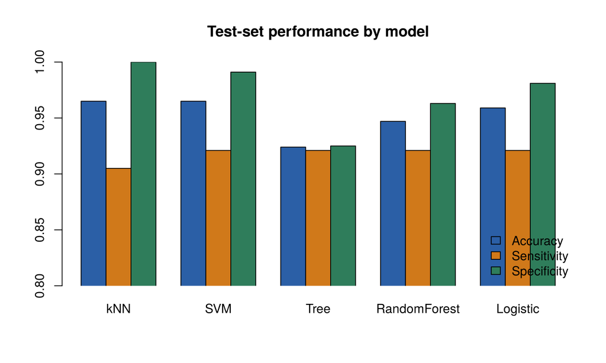

```r
barplot(t(test_metrics[, c("Accuracy", "Sensitivity", "Specificity")]), beside = TRUE,
        ylim = c(0.8, 1), xpd = FALSE, col = c("#2b5fa6", "#d0791a", "#2f7d5b"),
        legend.text = TRUE, args.legend = list(x = "bottomright", bty = "n"),
        main = "Test-set performance by model")
```

**Ask:** Logistic regression shows “glm.fit: fitted probabilities numerically 0 or 1” warnings with 30 features. Why? (With many correlated features the classes become almost perfectly separable, so the coefficients become unstable. Regularised versions such as `glmnet` handle this.)

## B6. Synthetic data with SMOTE

```r
set.seed(1)
dataSet <- sample_generator(1000, ratio = 0.70)   # 1000 cases, 2 features, 70% majority class
table(dataSet$result)
```

```
##
##   n   p
## 695 305
```

```r
generateData <- SMOTE(dataSet[, c(1, 2)], dataSet[, c(3)], K = 5)   # features, labels, neighbours
newDataSet <- generateData$data
table(newDataSet$class)
```

```
##
##   n   p
## 695 610
```

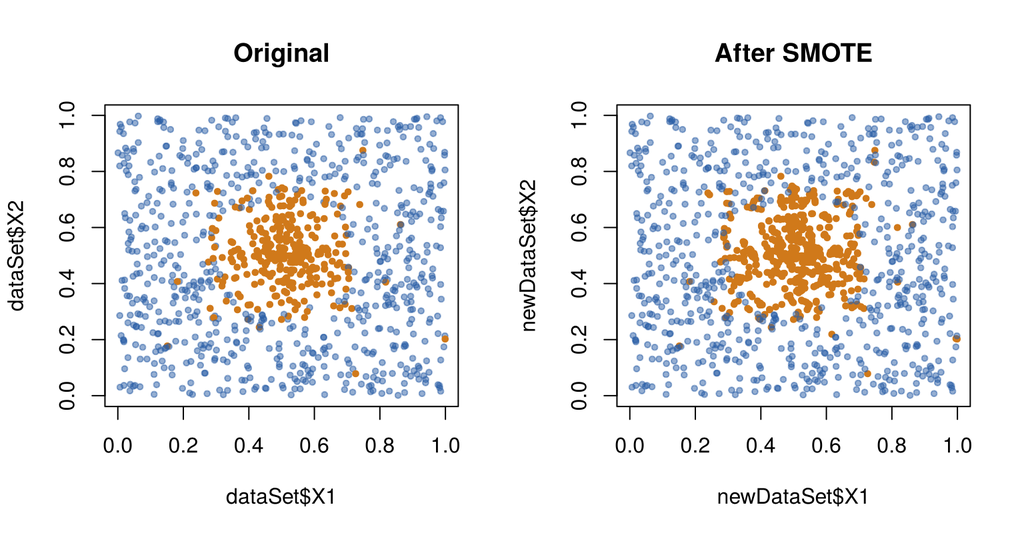

```r
par(mfrow = c(1, 2))
plot(dataSet$X1, dataSet$X2, col = ifelse(dataSet$result == "p", "#d0791a", "#2b5fa680"), pch = 19, cex = 0.6, main = "Original")
plot(newDataSet$X1, newDataSet$X2, col = ifelse(newDataSet$class == "p", "#d0791a", "#2b5fa680"), pch = 19, cex = 0.6, main = "After SMOTE")
```

```r
par(mfrow = c(1, 1))
```

### Does balancing help on the cancer data?

```r
# SMOTE on the TRAINING set only; the test set stays untouched
feat <- setdiff(names(trainingData), c("id", "diagnosis"))
sm <- SMOTE(trainingData[, feat], trainingData$diagnosis, K = 5)
balanced <- sm$data; balanced$class <- factor(balanced$class)
table(trainingData$diagnosis); table(balanced$class)
```

```
##
##   B   M
## 250 149
```

[output not shown]

```r
set.seed(1)
bal_model <- train(class ~ ., method = "knn", data = balanced, preProcess = c("center", "scale"))
confusionMatrix(predict(bal_model, testData[, feat]), testData$diagnosis, positive = "M")$byClass[c("Sensitivity", "Specificity")]
```

```
## Sensitivity Specificity
##   0.9047619   1.0000000
```

```r
confusionMatrix(pred_fixed, testData$diagnosis, positive = "M")$byClass[c("Sensitivity", "Specificity")]
```

```
## Sensitivity Specificity
##   0.9206349   1.0000000
```

### synthpop (whole synthetic datasets)

```r
library(synthpop)
syn_obj <- syn(trainingData[, c("diagnosis", "radius_mean", "texture_mean")], seed = 1)
compare(syn_obj, trainingData[, c("diagnosis", "radius_mean", "texture_mean")])
```

[output not shown]

If `synthpop` is not installed the chunk above is skipped; install it with `install.packages("synthpop")` or use the online tool at synthpop.shinyapps.io.

# Part C: Ethics discussion prompts (for your group project)

| Stage of your project | Questions to answer in your paper |
| --- | --- |
| Data access | What is the licence? Is any of it personal data? Is it anonymised or only pseudonymised? |
| Data quality | How was it collected? Who labelled it, and how reliable are the labels? What is missing? |
| Preparation | Did any decision (removing outliers, imputing) change the results? Is it documented? |
| Modelling | Could the model be biased against a group? Which errors are worse for which people? |
| Evaluation | Did you use a held-out test set or CV? Did you report several metrics and confidence intervals? |
| Deployment | Who is accountable? How would users know when to trust it? What if the data drift? |
| Sustainability | Is the code commented and reproducible (seeds, versions)? How costly was it to train? |

# Summary

| Task | R |
| --- | --- |
| Logistic regression | `glm(y ~ x, family = binomial)`, `predict(type = "response")` |
| Odds ratios | `exp(coef(model))` |
| ROC and AUC | `pROC::roc()`, `auc()` |
| Stratified split | `createDataPartition(y, p = 0.7)` |
| Train with CV | `train(y ~ ., method = "knn", trControl = trainControl("cv", 10))` |
| Evaluate | `confusionMatrix(pred, actual, positive = "M")` |
| Compare | `resamples()`, `bwplot()` |
| Balance classes | `smotefamily::SMOTE()` on the training set only |